# R Notebook

1.3.2 Industrial and Labor Relations In 1947, the United States Congress passed the Taft-Hartley Amendments to the Wagner Act. The original Wagner Act had permitted the unions to use a Closed Shop Contract unless prohibited by state law. The Taft-Hartley Amendments made the use of Closed Shop Contract illegal and gave individual states the right to prohibit union shops as well. These right-to-work laws have caused a wave of concern throughout the labor movement. A question of interest here is: What are the effects of these laws on the cost of living for a four-person family living on an intermediate budget in the United States?

To answer this question a data set consisting of 38 geographic locations has been assembled from various sources. The variables used are defined in Table 1.2. The Right-To-Work Laws data are given in Table 1.3 and can also be found at the book’s Website.

Variable COL Cost of living for a four-person family PD Population density (person per square mile) URate State unionization rate in 1978 Pop Population in 1975 Taxes Property taxes in 1972 Income Per capita income in 1974 RTWL Indicator variable (1 if there are right-to-work laws in the state and 0 otherwise)

```r
library(dplyr)
library(scatterplot3d)
library(psych)
library(ggplot2)
library(car)
library(gclus)
library(GGally)
library(fields)
require(ggplot2)
require(ggmap)
require(maps)
```

```r
library(ggplot2)
library(ggmap)
library(maps)
library(mapdata)
```

Start: Getting data ready

```r
data <- read.delim("P005.txt")
```

Here, I saved the geocode, longitude and lat, in a csv so we didn’t have to run geocode everytime.

```r
lonlat <- read.csv("lonlat.csv")
lonlat<-lonlat[,-1]
```

Adding the lon and lat variables to data.

```r
data$lon <- lonlat$lon
data$lat <- lonlat$lat
data$RTWL <- factor(data$RTWL)
```

Note: Wahsington was ran as washington state in geocode, so needed to run it as Washintion DC

```r
data[,1]<- as.character(data[,1])
data[36,1] <- "Washington DC"
```

```r
data[36,9] <- -77.03687
data[36,10] <- 38.90719
```

End: getting data ready ######################################### Start data vis

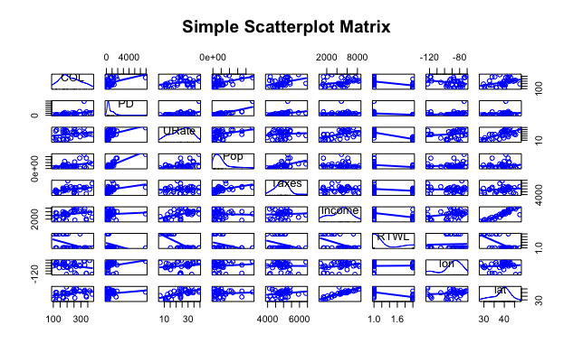

```r
 #Making a Basic scatter plot matrix

 scatterplotMatrix(~COL+PD+URate+Pop+Taxes+Income+RTWL+lon+lat ,data=data, smooth = FALSE, ellipse=
 FALSE, main="Simple Scatterplot Matrix")
```

```r
data1.1 <- data
data1.1$RTWL <- as.numeric(data1.1$RTWL)
```

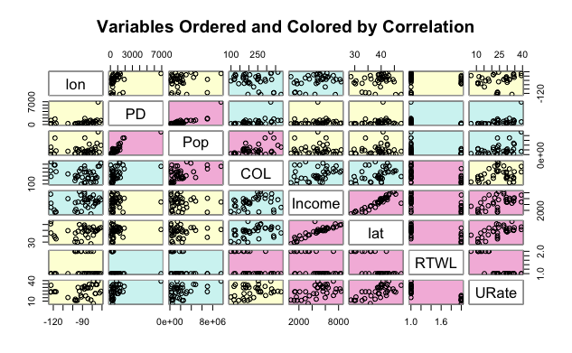

```r
dta.r <- abs(cor(data1.1[,-c(1,6)] )) # get correlations
dta.col <- dmat.color(dta.r) # get colors
# reorder variables so those with highest correlation
# are closest to the diagonal
dta.o <- order.single(dta.r)
cpairs(data1.1[,-c(1,6)], dta.o, panel.colors=dta.col, gap=.5,
main="Variables Ordered and Colored by Correlation" )
```

```r
dta.r
```

```
             COL         PD     URate        Pop     Income       RTWL        lon
COL    1.0000000 0.38838434 0.2687626 0.43346510 0.29002887 0.47046797 0.27132299
PD     0.3883843 1.00000000 0.4238896 0.83110681 0.07453903 0.27819735 0.24809612
URate  0.2687626 0.42388962 1.0000000 0.36928949 0.53000312 0.79373606 0.16939552
Pop    0.4334651 0.83110681 0.3692895 1.00000000 0.04282617 0.30494503 0.11892296
Income 0.2900289 0.07453903 0.5300031 0.04282617 1.00000000 0.51023621 0.29519927
RTWL   0.4704680 0.27819735 0.7937361 0.30494503 0.51023621 1.00000000 0.03590454
lon    0.2713230 0.24809612 0.1693955 0.11892296 0.29519927 0.03590454 1.00000000
lat    0.3883233 0.16328444 0.6483748 0.08363385 0.89771103 0.65651926 0.09452680
              lat
COL    0.38832334
PD     0.16328444
URate  0.64837485
Pop    0.08363385
Income 0.89771103
RTWL   0.65651926
lon    0.09452680
lat    1.00000000
```

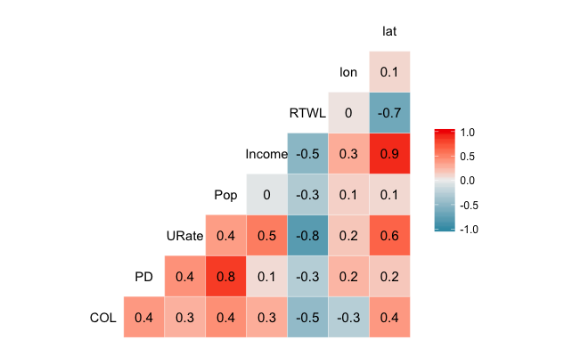

```r
# Correlation plot
ggcorr(data1.1[,-c(1,6)], palette = "RdBu", label = TRUE)
```

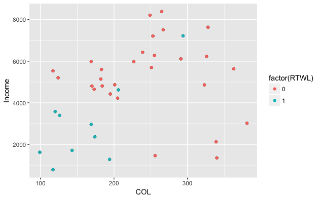

```r
A6A9 <- ggplot(data, aes(x = COL, y = Income)) + geom_point() + geom_point(aes(color = factor(RTWL)))
A6A9
```

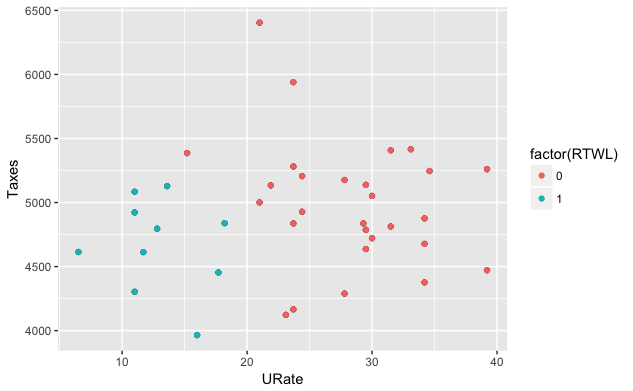

```r
A6A10 <- ggplot(data, aes(x = URate, y = Taxes)) + geom_point() + geom_point(aes(color = factor(RTWL)))
A6A10
```

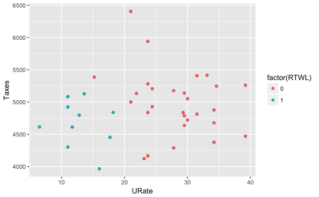

```r
A6A10 <- ggplot(data, aes(x = URate, y = Taxes)) + geom_point() + geom_point(aes(color = factor(RTWL)))
A6A10
```

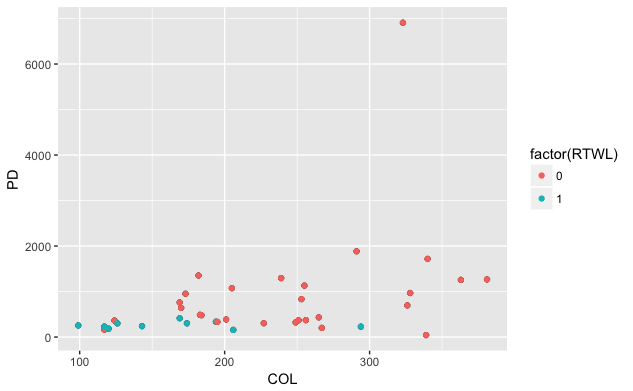

```r
A6A11 <- ggplot(data, aes(x = COL, y = PD)) + geom_point() + geom_point(aes(color = factor(RTWL)))
A6A11
```

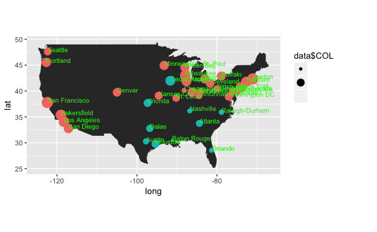

```r
usa <- map_data("usa")
ggplot() + geom_polygon(data = usa, aes(x=long, y = lat, group = group)) +
  coord_fixed(1.3) +
    geom_point( aes(x = data$lon, y = data$lat, color=factor(data$RTWL), size=data$COL)) +
  geom_text(data=data, aes(x=lon,y=lat, label = data$City),hjust=0, vjust=0, color="green", size= 2.9)
```

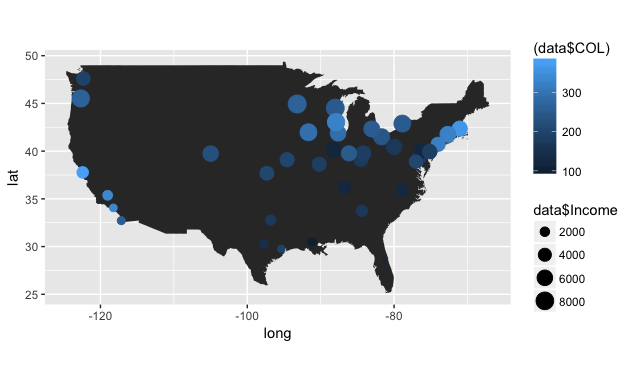

```r
usa <- map_data("usa")
ggplot() + geom_polygon(data = usa, aes(x=long, y = lat, group = group)) +
  coord_fixed(1.3) +
    geom_point( aes(x = data$lon, y = data$lat, color=(data$COL), size=data$Income))
```

This is a ‘picture of a’ map

End data vis #########################################

Start: AIC model slection Running the AIC for model WITHOUT longitude and Latitude

```r
model_null <- lm( COL~1, data = data)
model_full <- lm( COL~PD*URate*Pop*Taxes*Income*RTWL, data=data)
```

```r
step(model_null, scope=list(lower=model_null,
                        upper=model_full),
     direction="forward")
```

```
Start:  AIC=330.63
COL ~ 1

         Df Sum of Sq    RSS    AIC
+ RTWL    1     47936 168635 323.12
+ Pop     1     40692 175879 324.72
+ PD      1     32668 183903 326.41
+ Taxes   1     30041 186530 326.95
+ Income  1     18217 198354 329.29
+ URate   1     15644 200927 329.78
<none>                216571 330.63

Step:  AIC=323.12
COL ~ RTWL

         Df Sum of Sq    RSS    AIC
+ Pop     1   20080.7 148554 320.30
+ PD      1   15564.8 153070 321.44
+ Taxes   1   13212.3 155423 322.02
<none>                168635 323.12
+ URate   1    6412.4 162223 323.65
+ Income  1     731.4 167904 324.96

Step:  AIC=320.3
COL ~ RTWL + Pop

           Df Sum of Sq    RSS    AIC
+ URate     1   12993.2 135561 318.82
<none>                  148554 320.30
+ Income    1    4001.4 144553 321.26
+ Taxes     1    3209.1 145345 321.47
+ Pop:RTWL  1     455.8 148099 322.19
+ PD        1     250.6 148304 322.24

Step:  AIC=318.82
COL ~ RTWL + Pop + URate

             Df Sum of Sq    RSS    AIC
+ URate:RTWL  1   11218.7 124342 317.54
+ Income      1   10711.8 124849 317.70
```

[output cut: 65 more lines]

```
+ PD:URate           1    271.27 84970 313.07
+ URate:Income:RTWL  1    246.17 84996 313.08
+ PD:RTWL            1    139.38 85102 313.13
+ Pop:Income         1     77.12 85165 313.16
+ URate:Pop          1      7.69 85234 313.19

Call:
lm(formula = COL ~ RTWL + Pop + URate + Income + PD + RTWL:URate +
    RTWL:Income + URate:Income, data = data)

Coefficients:
 (Intercept)         RTWL1           Pop         URate        Income            PD
   9.185e+02    -6.417e+02     8.154e-06    -2.834e+01    -9.633e-02     2.227e-02
 RTWL1:URate  RTWL1:Income  URate:Income
   1.405e+01     6.164e-02     3.927e-03
```

Note: Correcting the Washingtion to Wahington DC issue changed the AIC result. We no longer need lat in the model.

```r
model1 <- lm(formula = COL ~ RTWL + Pop + URate + Income + PD + RTWL:URate +
    RTWL:Income + URate:Income, data = data)
  summary(model1)
```

```
Call:
lm(formula = COL ~ RTWL + Pop + URate + Income + PD + RTWL:URate +
    RTWL:Income + URate:Income, data = data)

Residuals:
     Min       1Q   Median       3Q      Max
-124.558  -30.586    1.361   29.240   95.228

Coefficients:
               Estimate Std. Error t value Pr(>|t|)
(Intercept)   9.185e+02  2.294e+02   4.005 0.000395 ***
RTWL1        -6.417e+02  1.709e+02  -3.755 0.000775 ***
Pop           8.154e-06  8.126e-06   1.003 0.323965
URate        -2.834e+01  9.083e+00  -3.120 0.004069 **
Income       -9.633e-02  3.941e-02  -2.444 0.020821 *
PD            2.227e-02  1.561e-02   1.427 0.164260
RTWL1:URate   1.405e+01  6.974e+00   2.014 0.053349 .
RTWL1:Income  6.164e-02  1.969e-02   3.130 0.003966 **
URate:Income  3.927e-03  1.542e-03   2.547 0.016431 *
---
Signif. codes:  0 ‘***’ 0.001 ‘**’ 0.01 ‘*’ 0.05 ‘.’ 0.1 ‘ ’ 1

Residual standard error: 54.22 on 29 degrees of freedom
Multiple R-squared:  0.6064,    Adjusted R-squared:  0.4978
F-statistic: 5.585 on 8 and 29 DF,  p-value: 0.0002538
```

AIC with lon and lat

```r
model_null2 <- lm( COL~1, data = data)
model_full2 <- lm( COL~PD*URate*Pop*Taxes*Income*RTWL*lon*lat, data=data)
```

```r
step(model_null2, scope=list(lower=model_null2,
                        upper=model_full2),
     direction="forward")
```

```
Start:  AIC=330.63
COL ~ 1

         Df Sum of Sq    RSS    AIC
+ RTWL    1     47936 168635 323.12
+ Pop     1     40692 175879 324.72
+ PD      1     32668 183903 326.41
+ lat     1     32658 183913 326.42
+ Taxes   1     30041 186530 326.95
+ Income  1     18217 198354 329.29
+ lon     1     15943 200628 329.72
+ URate   1     15644 200927 329.78
<none>                216571 330.63

Step:  AIC=323.12
COL ~ RTWL

         Df Sum of Sq    RSS    AIC
+ Pop     1   20080.7 148554 320.30
+ PD      1   15564.8 153070 321.44
+ lon     1   14037.8 154597 321.82
+ Taxes   1   13212.3 155423 322.02
<none>                168635 323.12
+ URate   1    6412.4 162223 323.65
+ lat     1    2402.8 166232 324.58
+ Income  1     731.4 167904 324.96

Step:  AIC=320.3
COL ~ RTWL + Pop

           Df Sum of Sq    RSS    AIC
+ lon       1   19354.2 129200 317.00
+ URate     1   12993.2 135561 318.82
<none>                  148554 320.30
+ lat       1    5326.0 143228 320.92
+ Income    1    4001.4 144553 321.26
+ Taxes     1    3209.1 145345 321.47
+ Pop:RTWL  1     455.8 148099 322.19
+ PD        1     250.6 148304 322.24

```

[output cut: 79 more lines]

```
+ PD:RTWL       1    118.55 58026 296.58
+ Income:RTWL   1     49.05 58095 296.63
+ PD:lon        1     14.46 58130 296.65
+ Pop:RTWL      1      0.18 58144 296.66
+ Taxes         1      0.09 58144 296.66

Call:
lm(formula = COL ~ RTWL + Pop + lon + Income + URate + PD + lon:Income,
    data = data)

Coefficients:
(Intercept)        RTWL1          Pop          lon       Income        URate
 -5.383e+02   -4.777e+01    6.651e-06   -8.030e+00    1.474e-01   -5.362e+00
         PD   lon:Income
  2.685e-02    1.323e-03
```

```r
summary(model2)
```

```
Call:
lm(formula = COL ~ RTWL + Pop + lon + Income + URate + PD + lon:Income,
    data = data)

Residuals:
   Min     1Q Median     3Q    Max
-64.72 -28.17 -13.11  25.28 100.98

Coefficients:
              Estimate Std. Error t value Pr(>|t|)
(Intercept) -5.383e+02  1.545e+02  -3.483 0.001545 **
RTWL1       -4.777e+01  3.009e+01  -1.588 0.122836
Pop          6.651e-06  6.611e-06   1.006 0.322443
lon         -8.030e+00  1.455e+00  -5.518 5.39e-06 ***
Income       1.474e-01  3.015e-02   4.888 3.20e-05 ***
URate       -5.362e+00  1.585e+00  -3.384 0.002006 **
PD           2.685e-02  1.257e-02   2.135 0.041016 *
lon:Income   1.323e-03  2.992e-04   4.420 0.000119 ***
---
Signif. codes:  0 ‘***’ 0.001 ‘**’ 0.01 ‘*’ 0.05 ‘.’ 0.1 ‘ ’ 1

Residual standard error: 44.02 on 30 degrees of freedom
Multiple R-squared:  0.7315,    Adjusted R-squared:  0.6689
F-statistic: 11.68 on 7 and 30 DF,  p-value: 4.537e-07
```

COL ~ RTWL + Pop + lon + Income + URate + PD + lon:Income

# Col = -538+ -48(RTWL) + 6.7e-06(Pop) + -8(lon) + .14(Income) + -5(URate) + .027(PD) + 1.3e-03(lon)(Income)

```r
colnames(COSw)<-c("x","y")
colnames(COSe)<-c("x","y")
```

```r
inc <- c(-300:300, by=50)
```

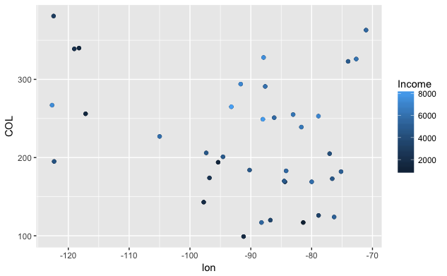

```r
A6A12 <- ggplot(data, aes(x = lon, y = COL)) + geom_point() + geom_point(aes(color = Income))
A6A12
```

for (i in 1:length(inc)) { abline( -8*(inc[i]), 1.3e-03*(inc[i])) }

```r
abline( -8*(-120), -.156)
abline(-8*(-80),-.104)
```

```r
library(colorRamps)
library(grDevices)
```

```r
lon <- seq(min(data$lon),max(data$lon), by=10)
Income <- seq(min(data$Income),max(data$Income), by=10)
gg <- expand.grid(lon=lon, Income=Income)
```

```r
# prediction from the linear model
gg$COL <-predict(fit,newdata=gg)
```

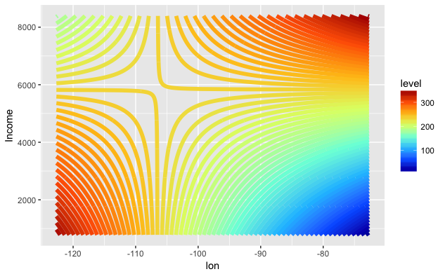

```r
jet.colors <- colorRampPalette(matlab.like(9))
ggplot(gg, aes(x=lon, y=Income, z=COL))+
  stat_contour(aes(color=..level..),binwidth=5, size=2)+
  scale_color_gradientn(colours=jet.colors(8))
```

```r
summary(fit)
```

[output not shown]

End: AIC model selection ###################### Start Model Assumption Check

Normal prob plot

```r
# qq plot for studentized resid
qqPlot(model1, main="QQ Plot")
```

[output not shown]

Pred. vs StRes.

```r
residualPlots(model1)
```

[output not shown]

```r
# Assessing Outliers
outlierTest(model1) # Bonferonni p-value for most extreme obs
qqPlot(model1, main="QQ Plot") #qq plot for studentized resid
leveragePlots(model1) # leverage plots
```

[output not shown]

```r
# Influential Observations
# added variable plots
avPlots(model1)
# Cook's D plot
# identify D values > 4/(n-k-1)
cutoff <- 4/((nrow(mtcars)-length(model1$coefficients)-2))
plot(model1, which=4, cook.levels=cutoff)
# Influence Plot
influencePlot(model1,   id="identify", main="Influence Plot", sub="Circle size is proportial to Cook's Distance" )
```

[output not shown]

```r
# Normality of Residuals
# qq plot for studentized resid
qqPlot(model1, main="QQ Plot")
# distribution of studentized residuals
library(MASS)
sresid <- studres(model1)
hist(sresid, freq=FALSE,
   main="Distribution of Studentized Residuals")
xmodel1<-seq(min(sresid),max(sresid),length=40)
ymodel1<-dnorm(xmodel1)
lines(xmodel1, ymodel1)
```

[output not shown]

```r
# Evaluate homoscedasticity
# non-constant error variance test
ncvTest(model1)
# plot studentized residuals vs. model1ted values
spreadLevelPlot(model1)
```

[output not shown]

```r
# Evaluate Collinearity
vif(model1) # variance inflation factors
sqrt(vif(model1)) > 2 # problem?
```

[output not shown]

```r
# Test for Autocorrelated Errors
durbinWatsonTest(model1)
```

[output not shown]

```r
# Global test of model assumptions
library(gvlma)
gvmodel <- gvlma(model1)
summary(gvmodel)
```

[output not shown]